# Psychometrics Report

2026-01-13

[output not shown]

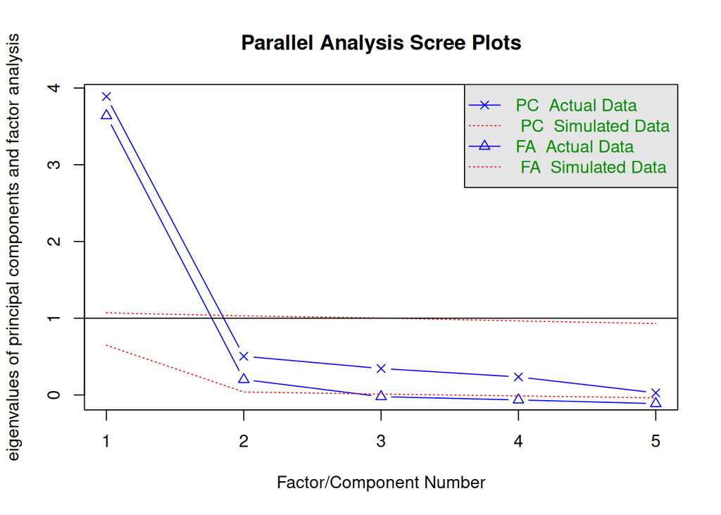

```
## Parallel analysis suggests that the number of factors =  2  and the number of components =  1
```

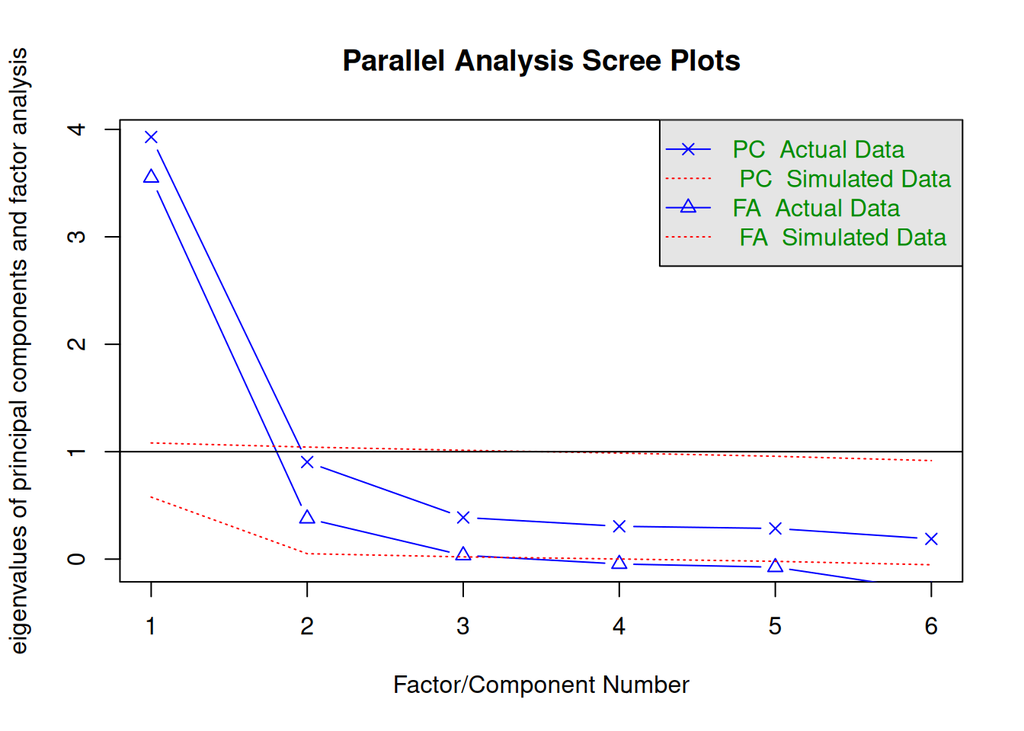

```
## Parallel analysis suggests that the number of factors =  2  and the number of components =  1
```

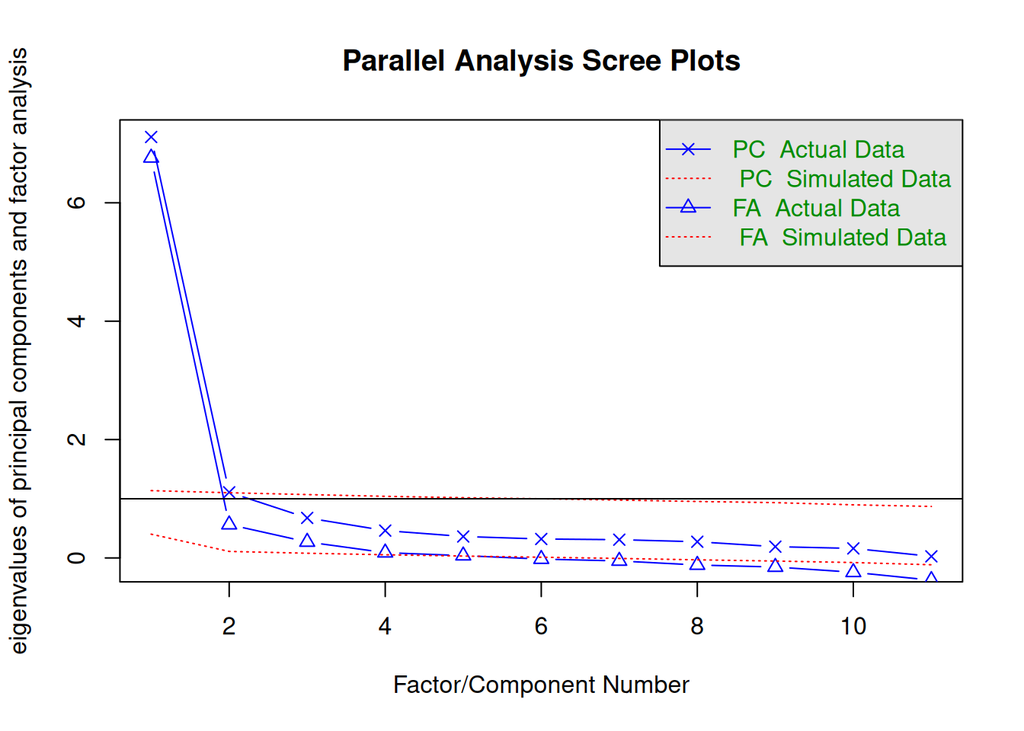

```
## Parallel analysis suggests that the number of factors =  4  and the number of components =  1
```

Table 1: Psychometrics of fatigue scales

| variable | items | Parameters | chisq | df | cfi | tli | rmsea | srmr | comp_rel | kaiser | par_factors | par_components | min_L | max_L |
| --- | --- | --- | --- | --- | --- | --- | --- | --- | --- | --- | --- | --- | --- | --- |
| cis4 | 5 | 35 | 270.8755 | 5 | 0.9999880 | 0.9999761 | 0.1967256 | 0.0491085 | 0.9666844 | 0 | 2 | 1 | 0.74 | 1.00 |
| sql | 6 | 30 | 497.7337 | 9 | 0.9875402 | 0.9792337 | 0.1963874 | 0.0877237 | 0.9612003 | 0 | 2 | 1 | 0.75 | 0.94 |
| combined | 11 | 65 | 2208.3825 | 44 | 0.9999026 | 0.9998783 | 0.1920992 | 0.0890419 | 1.0232679 | 0 | 4 | 1 | 0.66 | 1.00 |

A one-dimensional model has very high, near-perfect, composite reliability.

The factor loadings for all models are high (between 0.66 - 1.00).

Note that two items are perfectly correlated: CIS4_2 and CIS4_7. That means that these items do not convey unique information. They are redundant.

[figure not shown]

Figure 1: Graphical representation of the CIS4 model

[figure not shown]

Figure 2: Graphical representation of the SQL model

## 1 Multi-Trait Multi-Factor Model

We could also consider a model where the item responses load onto one common factor, and onto two distinct (scale-specific) factors. This model, too, fits very well.

Table 2: MTMF model fit

| Parameters | chisq | df | cfi | tli | rmsea | srmr |
| --- | --- | --- | --- | --- | --- | --- |
| 77 | 231.9901 | 32 | 0.999991 | 0.9999845 | 0.0684722 | 0.0313087 |

What we see in the table below is that all items load highly on a common factor, meaning that they all measure one underlying construct well. The lowest loading items are SQL 5 and 6.

Most items load little on their scale-specific variables, indicating little scale-specific variance. Some items are exceptions to this.

Table 3: Loadings in MTMM model

| rhs | C | CIS4 | SQL |
| --- | --- | --- | --- |
| cis4_1 | -0.90 | 0.12 | NA |
| cis4_2 | -0.85 | 0.51 | NA |
| cis4_3 | -0.78 | 0.05 | NA |
| cis4_4 | -0.88 | 0.10 | NA |
| cis4_7 | -0.83 | 0.57 | NA |
| sql_1 | -0.92 | NA | -0.02 |
| sql_2 | -0.87 | NA | 0.16 |
| sql_3 | -0.89 | NA | 0.24 |
| sql_4 | -0.86 | NA | 0.27 |
| sql_5 | -0.54 | NA | 0.70 |
| sql_6 | -0.53 | NA | 0.65 |